# Practice Project Report

Chirag Ghosh, Ryan Marshall, Sam Warg

2023-01-22

## Intro

For this analysis, we consider the nycflights13 data set, containing observations on all flights departing the three major New York City Airports - JFK, Newark, and LaGuardia - in 2013. The research goal for this project was to discover insights regarding flight delays, and to provide any suggestions to the organization responsible for mantaining these airports - The Port Authority of New York and New Jersey.

## Data

First, we must load the nycflights13 package to access our data, along with other packages that will be used in this analysis.

```r
library(nycflights13)
library(skimr)
library(tidyverse)
library(ggplot2)
library(lubridate)
library(janitor)
library(caret)
library(MASS)
library(Hmisc)
```

The data set includes a total of five tables. The core of this analysis will be based on the **flights** table, which includes the on-time data for all flights departing the 3 NYC airports in 2013. To help us further gain insights, we have hourly meteorological data for the 3 airports from the **weather** table, metadata on the planes which carry the flights from the **planes** table, metadata about airports, including the 3 NYC airports as well as ones that they fly to from the **airports** table, and finally the full names of airline carriers, which are abbreviated in the flights table, from the **airlines** table.

From this data set, we will primarily be considering the **weather** and **planes** supporting data, in addition to the core **flights** data. We will merge these tables to a final data set, describing the flight data along with the type of plane carrying that flight and the weather at the hour of scheduled departure. Notably, there are some missing weather observations, as well as some plane tail numbers that don’t show up in the **planes** table. For this reason, we will use left joins for the flights data, to ensure that we keep all flights even if they are missing weather and/or plane metadata.

```r
new_dat <- flights %>%
  dplyr::select(-c(day, month, year, hour)) %>% # Remove redundant columns before the join
  left_join(weather, by = c("origin", "time_hour")) %>%
  left_join(planes, by = 'tailnum') %>%
  rename(year_manufactured = year.y)  # Make clear that "year" from planes table refers to manufacture year, not year of flight
```

In this data set, we have the departure delay in minutes. We are most interested in flights that see significant delays which will most impact travelers. For this reason, we define a new binary column indicating whether we see a delay of 20 minutes or greater, or if the flight was cancelled entirely. Additionally, we would like to consider the day of the week when flights are scheduled, so we will add this as a new column as well. Finally, we could see that a set of 8 airlines dominate these flights (93% of all flights being carried by the top 8 airlines), we will recode flights that come from any carrier other than these top 8 as “Other” to avoid consideration of airlines with a minuscule number of observations.

```r
# top 9 carriers = 97% of flights
top_carriers <- new_dat %>%
  group_by(carrier) %>%
  count %>%
  arrange(desc(n)) %>%
  head(8) %>%
  pull(carrier)

new_dat <- new_dat %>%
  mutate(day_of_week = factor(lubridate::wday(time_hour, label=T), ordered=F),
         delayed = dep_delay >= 20 | is.na(dep_time),
         carrier = ifelse(carrier %in% top_carriers, carrier, "Other"))
View(new_dat)
```

## Exploratory Data Analysis

Before going into deeper analysis of specific data sets, some preliminary charts and graphs were made. These help us get better idea of our response variable, dep_delay. Initial trends can be spotted and most importantly the right questions can be developed. The first thing departure delays was compared to was time. More specifically, delays throughout the day and the year. This first plot immediately shows a trend throughout the day.

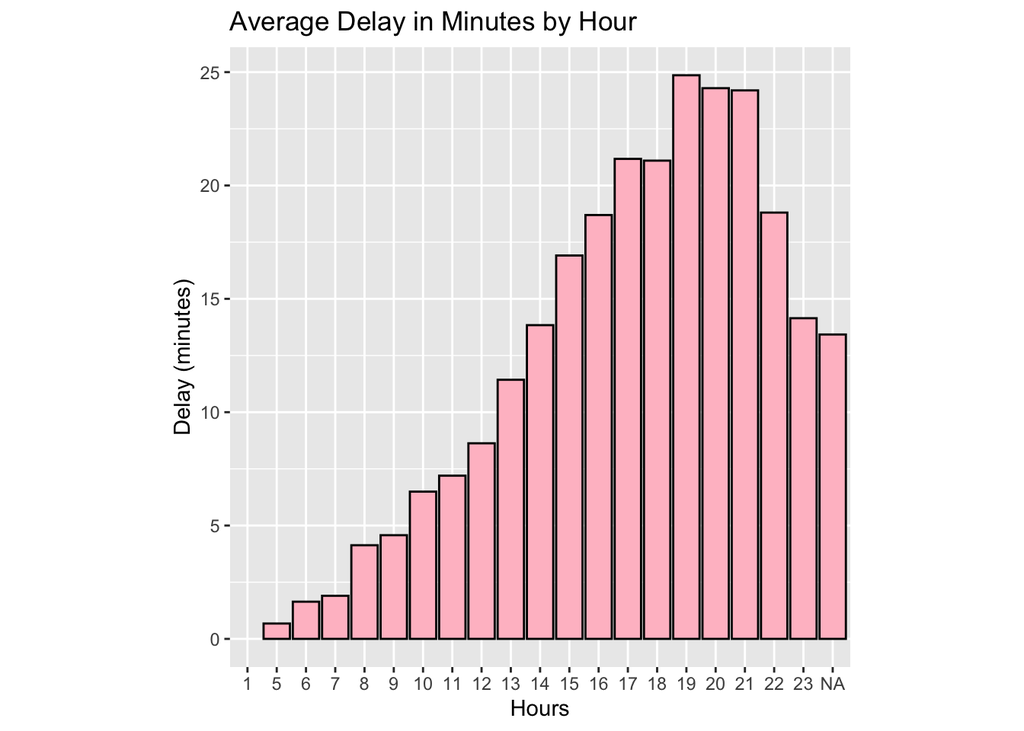

```r
hour_hist <- ggplot(new_dat, aes(x=factor(hour), y=dep_delay)) + stat_summary(fun.y="mean", geom="bar", color = 'black' ,fill = c('pink'))+ theme(aspect.ratio=1)
print(hour_hist + ggtitle("Average Delay in Minutes by Hour") + labs(x= "Hours", y="Delay (minutes)"))
```

.  
One of the most obvious trends for delays is that it increases hour by hour from 5am and peaks between 7-9pm. We can now ask does this happen due to chance, human error or other factors. Further research finds that flight schedules and delays are cascading. Meaning a delayed flight at the beginning of the day can effect the later ones which we can see. Then we can dive into if weather factors are effecting these flights throughout the day as well. Next, we look at delays through the year.

```
## No summary function supplied, defaulting to `mean_se()`
```

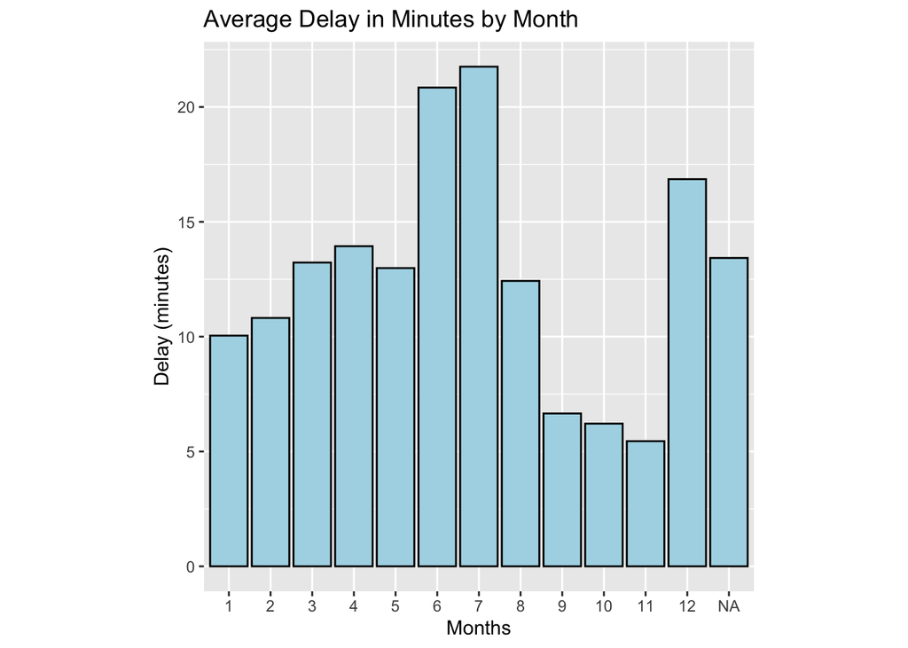

```r
month_hist <- ggplot(new_dat, aes(x=factor(month), y=dep_delay)) + stat_summary(geom="bar", color = 'black' ,fill = c('lightblue'))+ theme(aspect.ratio=1)
print(month_hist + ggtitle("Average Delay in Minutes by Month") + labs(x= "Months", y="Delay (minutes)"))
```

.  
The spike in June, July and December also indicate weather could be a reason for delays although they have vastly different weather in these two parts of the year.

The next part of our exploratory data analysis involved the weather variables. To decide which variables could be removed because they are highly correlated with another, a correlation matrix was fit to the numeric variables from the weather dataset.

```r
num_weather <- dplyr::select(new_dat, c("temp", "dewp", "humid", "wind_dir",
                                         "wind_speed", "wind_gust", "precip", "pressure", "visib"))
corr_matrix <- rcorr(as.matrix(num_weather))
corr_matrix[1]
```

```
## $r
##                   temp       dewp       humid    wind_dir  wind_speed
## temp        1.00000000  0.8822646  0.03551974 -0.09993133 -0.14684839
## dewp        0.88226464  1.0000000  0.49224588 -0.23597761 -0.22123007
## humid       0.03551974  0.4922459  1.00000000 -0.32495657 -0.19224936
## wind_dir   -0.09993133 -0.2359776 -0.32495657  1.00000000  0.34156638
## wind_speed -0.14684839 -0.2212301 -0.19224936  0.34156638  1.00000000
## wind_gust  -0.33016684 -0.2779602  0.05332652  0.06916820  0.88303198
## precip      0.01034082  0.1006320  0.23610746 -0.06800010  0.03789609
## pressure   -0.24597425 -0.2781755 -0.15927698 -0.20928477 -0.21535299
## visib       0.10237192 -0.1283344 -0.54868375  0.20886855  0.05810831
##              wind_gust      precip    pressure       visib
## temp       -0.33016684  0.01034082 -0.24597425  0.10237192
## dewp       -0.27796024  0.10063203 -0.27817550 -0.12833440
## humid       0.05332652  0.23610746 -0.15927698 -0.54868375
## wind_dir    0.06916820 -0.06800010 -0.20928477  0.20886855
## wind_speed  0.88303198  0.03789609 -0.21535299  0.05810831
## wind_gust   1.00000000  0.07012834 -0.24062720 -0.13580529
## precip      0.07012834  1.00000000 -0.08814833 -0.31621929
## pressure   -0.24062720 -0.08814833  1.00000000  0.10777425
## visib      -0.13580529 -0.31621929  0.10777425  1.00000000
```

From this, it can be seen that the wind_speed and wind_gust variables are highly correlated with one another, with a correlation coefficient of about 0.88.

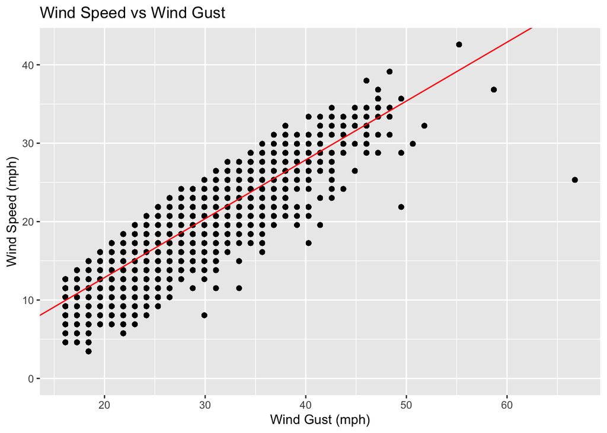

```r
b <- coef(lm(wind_speed ~ wind_gust, data = new_dat))[1]
m <- coef(lm(wind_speed ~ wind_gust, data = new_dat))[2]
ggplot(new_dat, aes(wind_gust, wind_speed)) + geom_point() +
  ggtitle("Wind Speed vs Wind Gust") + xlab("Wind Gust (mph)") +
  ylab("Wind Speed (mph)") +
  geom_abline(intercept = b, slope = m, colour = "red")
```

This plot confirms what was determined above. When the wind gust is high, so is the wind speed. Additionally, there is a lot less missing data for the wind_speed variable than the wind_gust variable; therefore, we can confidently exclude the wind_gust variable from modeling, reducing dimensionality.

There are also some other variables that have high correlation with one another. Those are the variables representing temperature, dewpoint, and humidity. Though each are related to one another, they all represent different characteristics regarding the weather. Due to this, decisions to keep or remove these predictors was determined later in the modeling process.

The next step of the exploratory data analysis for the weather data was determining weather or not we see a relationship between the different weather variables and the predictor dep_delay. To do so, bar graphs were fit with the predictor on the x-axis and dep_delay on the y-axis.

```r
temp_dat <- new_dat
# Creates temporary data frame to produce the bar graphs
```

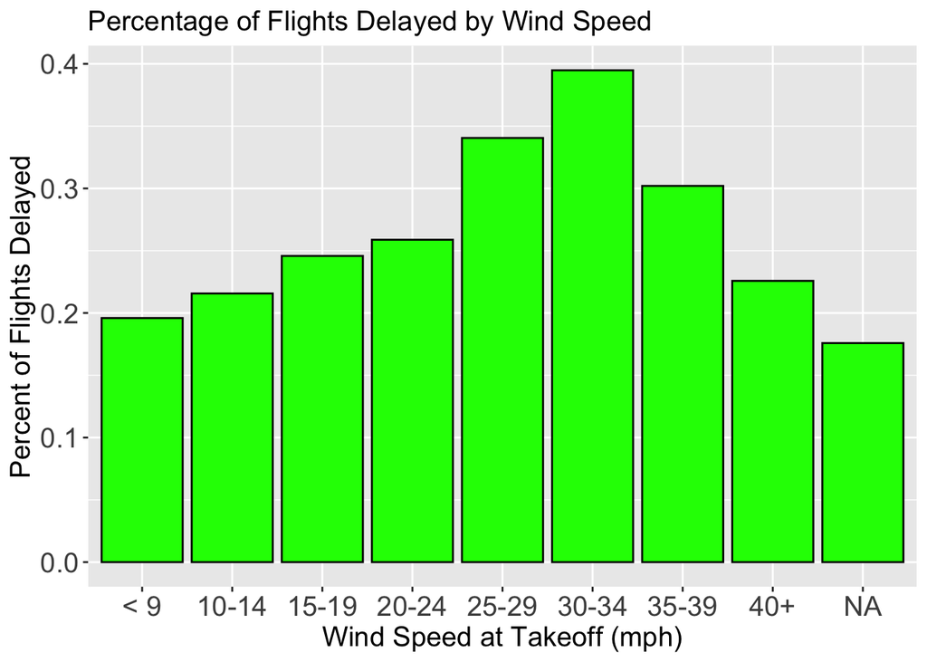

```r
temp_dat$wind_speed_group <- cut(temp_dat$wind_speed, breaks = c(seq(5, 45, by = 5)),
                       labels = c("< 9", "10-14", "15-19", "20-24", "25-29", "30-34", "35-39", "40+"))
# Groups wind speed into categories
wind_speed_delays <- temp_dat %>% mutate(delayed = dep_delay >= 20 | is.na(dep_time)) %>%
   tabyl(wind_speed_group, delayed)
# Creates table counting number of delayed and not delayed flights in each group
colnames(wind_speed_delays) <- c("wind_speed", "not_delayed", "delayed")
wind_speed_delays <- wind_speed_delays %>% mutate(percent_delayed = delayed / (delayed + not_delayed))
# Calculates percent of flights delayed in each group

ggplot(wind_speed_delays, aes(wind_speed, percent_delayed, fill = TRUE)) +
  geom_col(colour = "black") +
  scale_fill_manual(values = "green") +
  xlab("Wind Speed at Takeoff (mph)") + ylab("Percent of Flights Delayed") +
  ggtitle("Percentage of Flights Delayed by Wind Speed") + theme(legend.position = "none") +
  theme(axis.text=element_text(size=15), axis.title=element_text(size=15),
        plot.title=element_text(size=15))
```

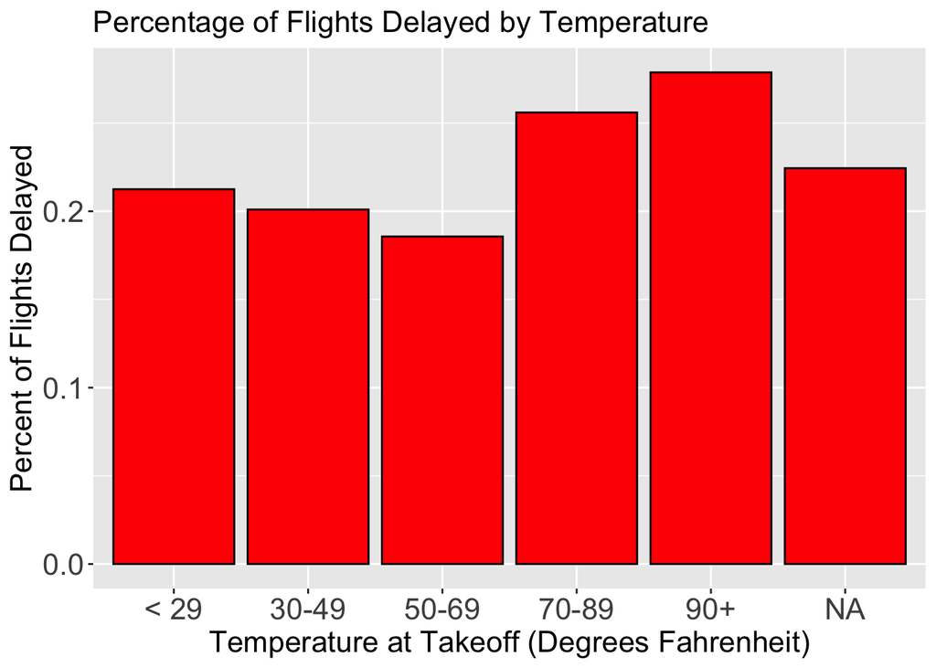

```r
temp_dat$temp_group <- cut(temp_dat$temp, breaks = c(seq(10, 110, by = 20)),
                                        labels = c("< 29", "30-49", "50-69", "70-89", "90+"))
# Groups temperature into categories
temp_delays <- temp_dat %>% mutate(delayed = dep_delay >= 20 | is.na(dep_time)) %>%
  tabyl(temp_group, delayed)
# Creates table counting number of delayed and not delayed flights in each group
colnames(temp_delays) <- c("temp", "not_delayed", "delayed")
temp_delays <- temp_delays %>% mutate(percent_delayed = delayed / (delayed + not_delayed))
# Calculates percent of flights delayed in each group

ggplot(temp_delays, aes(temp, percent_delayed, fill = TRUE)) +
  geom_col(colour = "black") +
  scale_fill_manual(values = "red") +
  xlab("Temperature at Takeoff (Degrees Fahrenheit)") + ylab("Percent of Flights Delayed") +
  ggtitle("Percentage of Flights Delayed by Temperature") + theme(legend.position = "none") +
  theme(axis.text=element_text(size=16), axis.title=element_text(size=16),
        plot.title=element_text(size=16))
```

This bar graph does not show as strong of a relationship between temp and dep_delay; however, there is a slightly higher proportion of delays in extremely cold and hot temperatures. This variable could still be considered in a model.

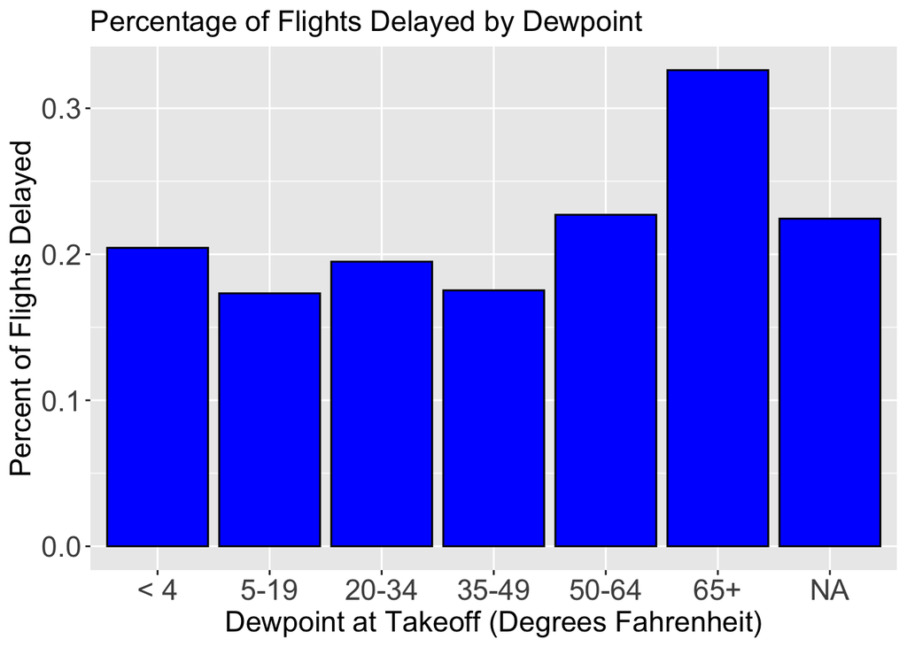

```r
temp_dat$dewp_group <- cut(new_dat$dewp, breaks = c(seq(-10, 80, by = 15)),
                                  labels = c("< 4", "5-19", "20-34", "35-49", "50-64", "65+"))
# Groups dewpoint into categories
dewp_delays <- temp_dat %>% mutate(delayed = dep_delay >= 20 | is.na(dep_time)) %>%
  tabyl(dewp_group, delayed)
# Creates table counting number of delayed and not delayed flights in each group
colnames(dewp_delays) <- c("dewp", "not_delayed", "delayed")
dewp_delays <- dewp_delays %>% mutate(percent_delayed = delayed / (delayed + not_delayed))
# Calculates percent of flights delayed in each group

ggplot(dewp_delays, aes(dewp, percent_delayed, fill = TRUE)) +
  geom_col(colour = "black") +
  scale_fill_manual(values = "blue") +
  xlab("Dewpoint at Takeoff (Degrees Fahrenheit)") + ylab("Percent of Flights Delayed") +
  ggtitle("Percentage of Flights Delayed by Dewpoint") + theme(legend.position = "none") +
  theme(axis.text=element_text(size=16), axis.title=element_text(size=16),
        plot.title=element_text(size=16))
```

This plot shows that in cases where the dewpoint is high, the percent of flights delayed is also high. This variable appears to have a similar relationship as the temperature variable, which explains the high correlation between the two.

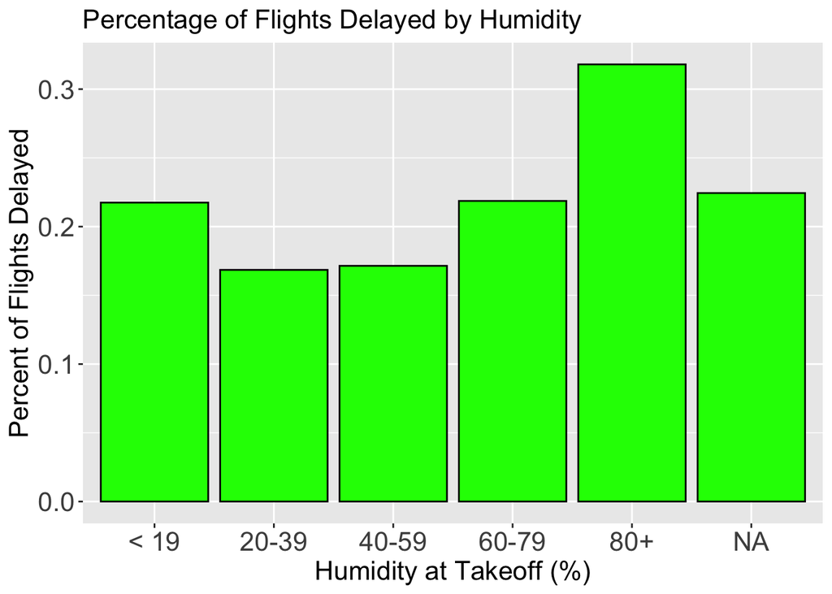

```r
temp_dat$humid_group <- cut(temp_dat$humid, breaks = c(seq(0, 100, by = 20)),
                                  labels = c("< 19", "20-39", "40-59", "60-79", "80+"))
# Groups dewpoint into categories
humid_delays <- temp_dat %>% mutate(delayed = dep_delay >= 20 | is.na(dep_time)) %>%
  tabyl(humid_group, delayed)
# Creates table counting number of delayed and not delayed flights in each group
colnames(humid_delays) <- c("humid", "not_delayed", "delayed")
humid_delays <- humid_delays %>% mutate(percent_delayed = delayed / (delayed + not_delayed))
# Calculates percent of flights delayed in each group

ggplot(humid_delays, aes(humid, percent_delayed, fill = TRUE)) +
  geom_col(colour = "black") +
  scale_fill_manual(values = "green") +
  xlab("Humidity at Takeoff (%)") + ylab("Percent of Flights Delayed") +
  ggtitle("Percentage of Flights Delayed by Humidity") + theme(legend.position = "none") +
  theme(axis.text=element_text(size=16), axis.title=element_text(size=16),
        plot.title=element_text(size=16))
```

A higher humidity appears to be correlated with a larger proportion of flights being delayed. This is also consistent with the temperature and dewpoint variables.

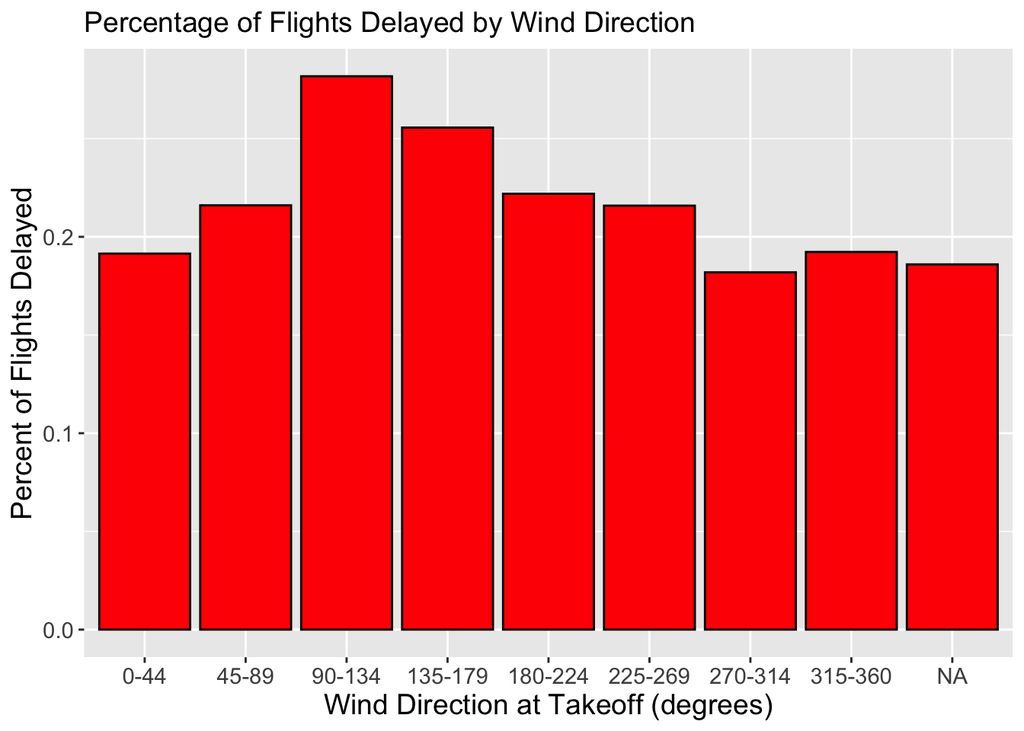

```r
temp_dat$wind_dir_group <- cut(temp_dat$wind_dir, breaks = c(seq(0, 360, by = 45)),
                                       labels = c("0-44", "45-89", "90-134", "135-179", "180-224",
                                                  "225-269", "270-314", "315-360"))
# Groups wind direction into categories
wind_dir_delays <- temp_dat %>% mutate(delayed = dep_delay >= 20 | is.na(dep_time)) %>%
  tabyl(wind_dir_group, delayed)
# Creates table counting number of delayed and not delayed flights in each group
colnames(wind_dir_delays) <- c("wind_dir", "not_delayed", "delayed")
wind_dir_delays <- wind_dir_delays %>% mutate(percent_delayed = delayed / (delayed + not_delayed))
# Calculates percent of flights delayed in each group

ggplot(wind_dir_delays, aes(wind_dir, percent_delayed, fill = TRUE)) +
  geom_col(colour = "black") +
  scale_fill_manual(values = "red") +
  xlab("Wind Direction at Takeoff (degrees)") + ylab("Percent of Flights Delayed") +
  ggtitle("Percentage of Flights Delayed by Wind Direction") + theme(legend.position = "none") +
  theme(axis.text=element_text(size=11), axis.title=element_text(size=14),
        plot.title=element_text(size=14))
```

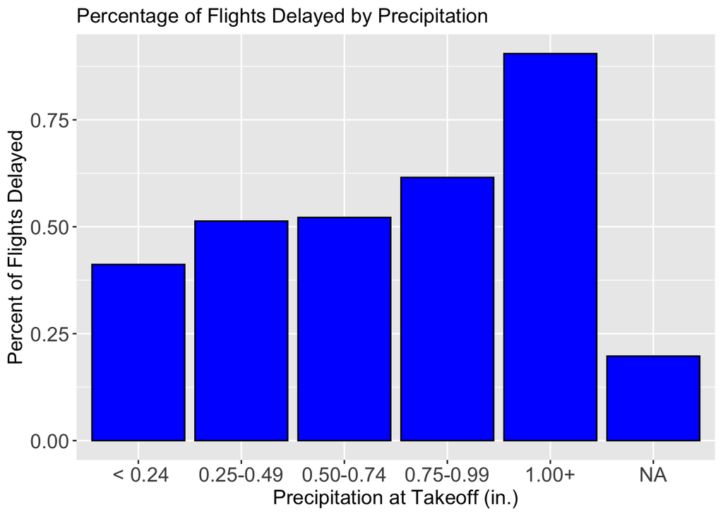

```r
temp_dat$precip_group <- cut(temp_dat$precip, breaks = c(seq(0, 1.25, by = 0.25)),
                                       labels = c(" < 0.24", "0.25-0.49", "0.50-0.74", "0.75-0.99", "1.00+"))
# Groups precipitation into categories
precip_delays <- temp_dat %>% mutate(delayed = dep_delay >= 20 | is.na(dep_time)) %>%
  tabyl(precip_group, delayed)
# Creates table counting number of delayed and not delayed flights in each group
colnames(precip_delays) <- c("precip", "not_delayed", "delayed")
precip_delays <- precip_delays %>% mutate(percent_delayed = delayed / (delayed + not_delayed))
# Calculates percent of flights delayed in each group

ggplot(precip_delays, aes(precip, percent_delayed, fill = TRUE)) +
  geom_col(colour = "black") +
  scale_fill_manual(values = "blue") +
  xlab("Precipitation at Takeoff (in.)") + ylab("Percent of Flights Delayed") +
  ggtitle("Percentage of Flights Delayed by Precipitation") + theme(legend.position = "none") +
  theme(axis.text=element_text(size=14), axis.title=element_text(size=14),
        plot.title=element_text(size=14))
```

As one would expect, the more precipitation that occurs, the higher the percentage of flights that are delayed. This would definitely be useful in the modeling stage.

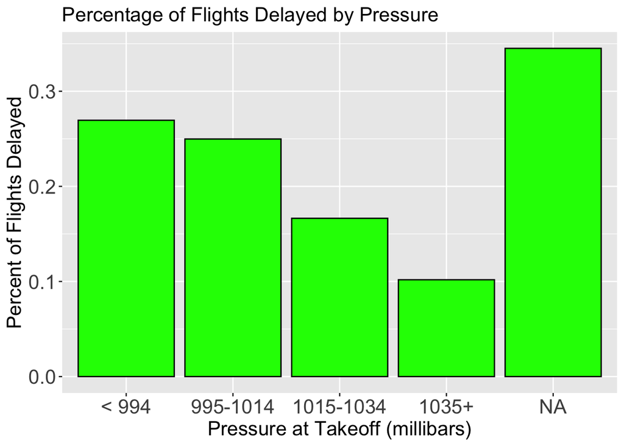

```r
temp_dat$pressure_group <- cut(temp_dat$pressure, breaks = c(seq(975, 1055, by = 20)),
                                    labels = c("< 994", "995-1014", "1015-1034", "1035+"))
# Groups pressure into categories
pressure_delays <- temp_dat %>% mutate(delayed = dep_delay >= 20 | is.na(dep_time)) %>%
  tabyl(pressure_group, delayed)
# Creates table counting number of delayed and not delayed flights in each group
colnames(pressure_delays) <- c("pressure", "not_delayed", "delayed")
pressure_delays <- pressure_delays %>% mutate(percent_delayed = delayed / (delayed + not_delayed))
# Calculates percent of flights delayed in each group

ggplot(pressure_delays, aes(pressure, percent_delayed, fill = TRUE)) +
  geom_col(colour = "black") +
  scale_fill_manual(values = "green") +
  xlab("Pressure at Takeoff (millibars)") + ylab("Percent of Flights Delayed") +
  ggtitle("Percentage of Flights Delayed by Pressure") + theme(legend.position = "none") +
  theme(axis.text=element_text(size=16), axis.title=element_text(size=16),
        plot.title=element_text(size=16))
```

It appears as if pressure has a lot of predictive value, as an increase in pressure very clearly results in a decrease in percent of flights delayed. This should be considered in model selection.

## Data Modelling

Using some of the associations we found in the exploratory phase, we would now like to fit some models that will help in predicting flight delays as well as provide insight into how these features impact delay times. For this project, we will fit two types of models. First we will use a linear model to predict delay time as a continuous response. For the other model, we will use logistic regression to predict whether or not we will see a significant delay (20 minutes or greater delay time) or flight cancellation.

First, we will reduce the data set down to include only the candidate features we have identified to use as predictors, in addition to the response variables. These candidates are wind speed, wind direction, temperature, visibility, hour of day, flight distance, carrier, airport of origin, precipitation, humidity, pressure, and day of the week.

```r
# Select features to be included in the model
features <- new_dat %>%
  dplyr::select(delayed, dep_delay, wind_speed, wind_dir, temp, visib, hour, distance, carrier, origin, precip, humid, pressure, day_of_week, dewp)
```

In the model fitting process, it is important to evaluate the out of sample predictive power of models. For this reason, we will split the data into a train and test set, with 70% of observations used for training and the remaining 30% for testing.

```r
# Add id column
features$id <- 1:nrow(features)

# Split data for testing and drop id column
train <- slice_sample(features, prop = 0.7)
test  <- anti_join(features, train, by = 'id')
train <- dplyr::select(train, -id)
test <- dplyr::select(test, -id)
```

From our EDA some variables and points were already transformed, removed or deemed insignificant. Narrowing the predictors, we can now also run stepwise AIC to see if the remaining variables are all significant. We run both forward and backward to see if they result in the same model.

```r
# "lower" and "upper" models
null = lm(dep_delay ~ 1, data = na.omit(train))
full = lm(dep_delay ~ ., data = na.omit(train))

# Forward search starting from the null model
stepAIC(null, scope = list(lower = null, upper = full),
        direction = "forward", k = 2)
```

```
## Start:  AIC=1449952
## dep_delay ~ 1
##
##               Df Sum of Sq       RSS     AIC
## + delayed      1 148041740 135160444 1302153
## + hour         1  10017374 273184810 1442758
## + pressure     1   3497344 279704840 1447471
## + carrier      8   3089794 280112389 1447776
## + dewp         1   2512391 280689793 1448173
## + humid        1   1867033 281335151 1448632
## + temp         1   1404441 281797742 1448961
## + visib        1   1066788 282135395 1449200
## + day_of_week  6    868088 282334096 1449350
## + origin       2    815145 282387039 1449380
## + precip       1    741463 282460721 1449430
## + wind_speed   1    295072 282907112 1449746
## + distance     1     47975 283154209 1449920
## + wind_dir     1     43465 283158719 1449923
## <none>                     283202184 1449952
##
## Step:  AIC=1302153
## dep_delay ~ delayed
##
##               Df Sum of Sq       RSS     AIC
## + dewp         1    396340 134764104 1301568
## + humid        1    328742 134831702 1301668
## + pressure     1    317457 134842987 1301685
## + hour         1    263994 134896450 1301764
## + carrier      8    247536 134912908 1301802
## + temp         1    197373 134963071 1301863
## + visib        1    151072 135009372 1301931
## + day_of_week  6     92417 135068027 1302028
## + precip       1     63919 135096524 1302060
## + origin       2     41606 135118838 1302095
## + distance     1     26374 135134070 1302116
## + wind_dir     1     23394 135137050 1302120
## + wind_speed   1      1532 135158912 1302152
## <none>                     135160444 1302153
##
## Step:  AIC=1301568
```

[output cut: 132 more lines]

```
##
##            Df Sum of Sq       RSS     AIC
## + origin    2   2992.73 133756296 1300114
## <none>                  133759289 1300114
## + temp      1    636.05 133758653 1300115
## + distance  1    397.43 133758892 1300116
##
## Step:  AIC=1300114
## dep_delay ~ delayed + dewp + hour + carrier + humid + pressure +
##     day_of_week + visib + wind_speed + precip + wind_dir + origin
##
##            Df Sum of Sq       RSS     AIC
## <none>                  133756296 1300114
## + temp      1    460.45 133755836 1300115
## + distance  1     43.67 133756253 1300116
```

```
##
## Call:
## lm(formula = dep_delay ~ delayed + dewp + hour + carrier + humid +
##     pressure + day_of_week + visib + wind_speed + precip + wind_dir +
##     origin, data = na.omit(train))
##
## Coefficients:
##    (Intercept)     delayedTRUE            dewp            hour       carrierAA
##       96.75176        69.36699         0.04131         0.28881        -0.09569
##      carrierB6       carrierDL       carrierEV       carrierMQ    carrierOther
##       -0.89692         0.14487         0.63011        -2.06783         2.49411
##      carrierUA       carrierUS           humid        pressure  day_of_weekMon
##        0.47548        -2.34499         0.05059        -0.10297         0.87461
## day_of_weekTue  day_of_weekWed  day_of_weekThu  day_of_weekFri  day_of_weekSat
##       -0.72172         0.37453         1.11837         0.31693        -1.12439
##          visib      wind_speed          precip        wind_dir       originJFK
##       -0.21652         0.06903        12.89847        -0.00129        -0.04668
##      originLGA
##       -0.32019
```

```r
# Backward elimination starting from the full model
stepAIC(full, scope = list(lower = null, upper = full),
        direction = "backward", k = 2)
```

```
## Start:  AIC=1300117
## dep_delay ~ delayed + wind_speed + wind_dir + temp + visib +
##     hour + distance + carrier + origin + precip + humid + pressure +
##     day_of_week + dewp
##
##               Df Sum of Sq       RSS     AIC
## - dewp         1        39 133755829 1300115
## - distance     1        46 133755836 1300115
## - temp         1       462 133756253 1300116
## - origin       2      2479 133758269 1300117
## <none>                     133755790 1300117
## - wind_dir     1      2566 133758356 1300119
## - precip       1      4641 133760432 1300122
## - humid        1      7564 133763354 1300126
## - visib        1      9833 133765623 1300130
## - wind_speed   1     21129 133776919 1300147
## - pressure     1     87578 133843368 1300246
## - day_of_week  6    106490 133862280 1300264
## - carrier      8    218742 133974532 1300428
## - hour         1    318917 134074707 1300591
## - delayed      1 129422910 263178700 1435352
##
## Step:  AIC=1300115
## dep_delay ~ delayed + wind_speed + wind_dir + temp + visib +
##     hour + distance + carrier + origin + precip + humid + pressure +
##     day_of_week
##
##               Df Sum of Sq       RSS     AIC
## - distance     1        46 133755876 1300113
## - origin       2      2448 133758277 1300115
## <none>                     133755829 1300115
## - wind_dir     1      2548 133758377 1300117
## - precip       1      4615 133760444 1300120
## - visib        1     11111 133766940 1300130
## - wind_speed   1     21188 133777017 1300145
## - temp         1     83106 133838935 1300237
## - pressure     1     87669 133843498 1300244
## - day_of_week  6    106859 133862688 1300263
## - humid        1    199191 133955020 1300411
## - carrier      8    218774 133974603 1300426
## - hour         1    319040 134074869 1300589
## - delayed      1 129431122 263186952 1435356
##
## Step:  AIC=1300113
## dep_delay ~ delayed + wind_speed + wind_dir + temp + visib +
##     hour + carrier + origin + precip + humid + pressure + day_of_week
##
##               Df Sum of Sq       RSS     AIC
## <none>                     133755876 1300113
## - origin       2      2784 133758659 1300113
## - wind_dir     1      2546 133758421 1300115
## - precip       1      4616 133760491 1300118
## - visib        1     11109 133766985 1300128
## - wind_speed   1     21197 133777072 1300143
## - temp         1     83223 133839099 1300236
## - pressure     1     87640 133843515 1300242
## - day_of_week  6    106872 133862747 1300261
## - humid        1    199194 133955070 1300409
## - carrier      8    236178 133992054 1300450
## - hour         1    318994 134074870 1300587
## - delayed      1 129431277 263187153 1435354
```

```
##
## Call:
## lm(formula = dep_delay ~ delayed + wind_speed + wind_dir + temp +
##     visib + hour + carrier + origin + precip + humid + pressure +
##     day_of_week, data = na.omit(train))
##
## Coefficients:
##    (Intercept)     delayedTRUE      wind_speed        wind_dir            temp
##       94.04711        69.36523         0.06952        -0.00126         0.03847
##          visib            hour       carrierAA       carrierB6       carrierDL
##       -0.19472         0.28824        -0.09741        -0.89905         0.14418
##      carrierEV       carrierMQ    carrierOther       carrierUA       carrierUS
##        0.62979        -2.06895         2.49271         0.47442        -2.34802
##      originJFK       originLGA          precip           humid        pressure
##       -0.04784        -0.31010        12.70068         0.07133        -0.10219
## day_of_weekMon  day_of_weekTue  day_of_weekWed  day_of_weekThu  day_of_weekFri
##        0.87540        -0.72798         0.38215         1.11909         0.32094
## day_of_weekSat
##       -1.12914
```

**Linear regression**

Fitting this model we get:

```r
linear.mod = lm(formula = dep_delay ~ distance + hour + dewp + wind_speed +
    precip + pressure + visib + origin * wind_dir, data = train)
summary(linear.mod)
```

```
##
## Call:
## lm(formula = dep_delay ~ distance + hour + dewp + wind_speed +
##     precip + pressure + visib + origin * wind_dir, data = train)
##
## Residuals:
##     Min      1Q  Median      3Q     Max
##  -72.45  -16.98   -8.80    1.31 1304.37
##
## Coefficients:
##                      Estimate Std. Error t value Pr(>|t|)
## (Intercept)         3.512e+02  1.283e+01  27.375  < 2e-16 ***
## distance           -7.831e-04  1.155e-04  -6.783 1.18e-11 ***
## hour                1.483e+00  1.778e-02  83.423  < 2e-16 ***
## dewp                1.380e-01  4.780e-03  28.877  < 2e-16 ***
## wind_speed          2.192e-01  1.724e-02  12.713  < 2e-16 ***
## precip              6.081e+01  6.821e+00   8.915  < 2e-16 ***
## pressure           -3.446e-01  1.249e-02 -27.584  < 2e-16 ***
## visib              -1.267e+00  6.180e-02 -20.493  < 2e-16 ***
## originJFK          -4.742e+00  4.451e-01 -10.653  < 2e-16 ***
## originLGA          -4.069e+00  4.377e-01  -9.296  < 2e-16 ***
## wind_dir           -5.577e-03  1.380e-03  -4.043 5.28e-05 ***
## originJFK:wind_dir  2.328e-03  1.927e-03   1.208   0.2271
## originLGA:wind_dir -4.052e-03  1.890e-03  -2.144   0.0321 *
## ---
## Signif. codes:  0 '***' 0.001 '**' 0.01 '*' 0.05 '.' 0.1 ' ' 1
##
## Residual standard error: 36.55 on 199800 degrees of freedom
##   (35930 observations deleted due to missingness)
## Multiple R-squared:  0.05737,    Adjusted R-squared:  0.05731
## F-statistic:  1013 on 12 and 199800 DF,  p-value: < 2.2e-16
```

While informative, many of these variables are with respect to each other. As we can see with our interaction term, some of these variables can be dependent on another and so the values may not exactly calculate the delay by simply plugging in a value. However, these values can serve to givethe Port Authority an idea about the amount/severity of a delay from these variables.

We would also like to evaluate the performance of this model on out of sample prediction. To evaluate this, we will predict on the test set and report the root mean squared error (RMSE).

```r
# Predict on the test set
pred.lm <- predict.lm(linear.mod, newdata = test)

# Report RMSE
rmse <- sqrt(mean((pred.lm - test$dep_delay)^2, na.rm=TRUE))
print(paste("RMSE for prediction on the test set =", round(rmse, 3)))
```

```
## [1] "RMSE for prediction on the test set = 36.723"
```

**Logistic regression**

In the interest of predicting significant delays/cancellations, we will also use logistic regression to predict a binary response. This model will predict the value “delayed” column, which again takes the value of “True” if the departure delay is at least 20 minutes or the departure time is *NA*, and takes the value “False” otherwise.

For this model, we will use a subset of the features that we have found to be associated with delays. Using only a subset of these features, rather than all of them, is necessary to eliminate issues of collinearity among predictors. The set of predictors will include wind speed, visibility, hour, distance, precipitation, day of week, and carrier. We will also include an interaction term between wind direction and origin, in order to account for the differences in how wind direction may impact delays across different airports, which will have different directions of their runways.

The model will be fit on the training set, and evaluated for accuracy on the test set. Here, we will fit the model and display the model summary.

```r
# Fit logistic model and print summary
logistic.mod <- glm(delayed ~ wind_speed  + wind_dir:origin  + visib + hour + distance + precip  + day_of_week + carrier, family = "binomial", data = train)
print(summary(logistic.mod))
```

```
##
## Call:
## glm(formula = delayed ~ wind_speed + wind_dir:origin + visib +
##     hour + distance + precip + day_of_week + carrier, family = "binomial",
##     data = train)
##
## Deviance Residuals:
##     Min       1Q   Median       3Q      Max
## -2.4598  -0.7195  -0.5245  -0.3295   2.7873
##
## Coefficients:
##                      Estimate Std. Error z value Pr(>|z|)
## (Intercept)        -2.190e+00  3.994e-02 -54.820  < 2e-16 ***
## wind_speed          3.295e-02  1.031e-03  31.970  < 2e-16 ***
## visib              -1.251e-01  2.610e-03 -47.938  < 2e-16 ***
## hour                1.345e-01  1.254e-03 107.262  < 2e-16 ***
## distance           -5.870e-05  9.204e-06  -6.377 1.80e-10 ***
## precip              3.130e+00  1.830e-01  17.102  < 2e-16 ***
## day_of_weekMon      2.982e-01  2.028e-02  14.704  < 2e-16 ***
## day_of_weekTue      1.524e-01  2.069e-02   7.369 1.72e-13 ***
## day_of_weekWed      1.378e-01  2.068e-02   6.664 2.67e-11 ***
## day_of_weekThu      4.550e-01  2.006e-02  22.687  < 2e-16 ***
## day_of_weekFri      3.524e-01  2.014e-02  17.497  < 2e-16 ***
## day_of_weekSat     -3.300e-02  2.292e-02  -1.440 0.149879
## carrierAA          -5.541e-01  2.981e-02 -18.586  < 2e-16 ***
## carrierB6          -3.240e-01  2.500e-02 -12.960  < 2e-16 ***
## carrierDL          -7.016e-01  2.765e-02 -25.375  < 2e-16 ***
## carrierEV           2.300e-01  2.646e-02   8.694  < 2e-16 ***
## carrierMQ          -2.333e-01  2.862e-02  -8.153 3.54e-16 ***
## carrierOther       -1.147e-01  3.135e-02  -3.660 0.000252 ***
## carrierUA          -3.913e-01  2.883e-02 -13.575  < 2e-16 ***
## carrierUS          -7.470e-01  3.383e-02 -22.083  < 2e-16 ***
## wind_dir:originEWR -2.096e-04  6.791e-05  -3.086 0.002030 **
## wind_dir:originJFK -1.142e-03  7.521e-05 -15.183  < 2e-16 ***
## wind_dir:originLGA -6.025e-04  7.073e-05  -8.517  < 2e-16 ***
## ---
## Signif. codes:  0 '***' 0.001 '**' 0.01 '*' 0.05 '.' 0.1 ' ' 1
##
## (Dispersion parameter for binomial family taken to be 1)
##
##     Null deviance: 236765  on 228828  degrees of freedom
## Residual deviance: 214065  on 228806  degrees of freedom
##   (6914 observations deleted due to missingness)
## AIC: 214111
##
## Number of Fisher Scoring iterations: 4
```

Next, we will use this model to predict on the test set, and evaluate performance.

```r
# Predict on out of sample
pred <- predict.glm(logistic.mod, newdata = test, type="response")
```

Now that we have the predicted responses from this model, we will assign each observation to either True or False, and compare this to the actual class labels from the test set. Here, we will use 0.5 as a cutoff, categorizing predicted responses above that level as “True” (predicting there will be a significant delay/cancellation) and responses below 0.5 as “False.”

We will then produce a confusion matrix of the predicted/actual responses to evaluate model performance.

```r
# Get predicted classes
pred_class <- factor(ifelse(pred>0.5,  "TRUE", "FALSE"), levels = c("TRUE", "FALSE"))
# Recode actual class as
actual_class <- factor(test$delayed, levels= c("TRUE", "FALSE"))

#create confusion matrix
confusionMatrix(pred_class, actual_class)
```

```
## Confusion Matrix and Statistics
##
##           Reference
## Prediction  TRUE FALSE
##      TRUE   1947  1256
##      FALSE 18928 76020
##
##                Accuracy : 0.7944
##                  95% CI : (0.7918, 0.7969)
##     No Information Rate : 0.7873
##     P-Value [Acc > NIR] : 3.198e-08
##
##                   Kappa : 0.1114
##
##  Mcnemar's Test P-Value : < 2.2e-16
##
##             Sensitivity : 0.09327
##             Specificity : 0.98375
##          Pos Pred Value : 0.60787
##          Neg Pred Value : 0.80065
##              Prevalence : 0.21268
##          Detection Rate : 0.01984
##    Detection Prevalence : 0.03263
##       Balanced Accuracy : 0.53851
##
##        'Positive' Class : TRUE
##
```

To rectify this problem, we will lower the previously used threshold of 0.5 for predicting a delay. We will instead use a threshold of 0.21, which is the actual level proportion of flights that see significant delay or cancellation.

```r
# Get predicted classes
pred_class <- factor(ifelse(pred>0.21,  "TRUE", "FALSE"), levels = c("TRUE", "FALSE"))
# Recode actual class as
actual_class <- factor(test$delayed, levels= c("TRUE", "FALSE"))

#create confusion matrix
confusionMatrix(pred_class, actual_class)
```

```
## Confusion Matrix and Statistics
##
##           Reference
## Prediction  TRUE FALSE
##      TRUE  14262 28275
##      FALSE  6613 49001
##
##                Accuracy : 0.6445
##                  95% CI : (0.6415, 0.6475)
##     No Information Rate : 0.7873
##     P-Value [Acc > NIR] : 1
##
##                   Kappa : 0.2302
##
##  Mcnemar's Test P-Value : <2e-16
##
##             Sensitivity : 0.6832
##             Specificity : 0.6341
##          Pos Pred Value : 0.3353
##          Neg Pred Value : 0.8811
##              Prevalence : 0.2127
##          Detection Rate : 0.1453
##    Detection Prevalence : 0.4334
##       Balanced Accuracy : 0.6587
##
##        'Positive' Class : TRUE
##
```

## Insights

Through this analysis of all the predictors and various conclusions, we have some reccomendations. While we cannot control the weather, it could be beneficial to focus on scheduling flights better by perhaps lowering the number of flights in the morning to avoid the carry over delays that are occurring. Additionally, use some of the conclusions about the weather to better estimate the severity of how much a flight will be delayed! This in turn can effect when flights are scheduled throughout a day and even the year while also allowing to be able to more precisely inform passengers of expected departure delays.